# 흡연과 여러 변수들과의 관계

변수: 당뇨, 비만, 3대암(위암, 간암, 폐암)

### 비만을 제외한 나머지 변수들은, 흡연자 그룹이 비흡연자 그룹에 비해 발병률이 높게 나타날 것이다. 특히 폐암의 경우는 두드러진 차이를 보일 것으로 예상된다. 또한, 하루평균 흡연량이 많을 수록 질병의 발병률이 더 높게 나타날 것이다.

```python
import numpy as np
import numpy.random as random
import scipy as sp
import scipy.stats as stats
import pandas as pd
from pandas import Series, DataFrame

# 시각화 라이브러리
import matplotlib.pyplot as plt
import matplotlib as mpl
import seaborn as sns
%matplotlib inline

# 소수점 3자리까지 표시
%precision 3
```

```
'%.3f'
```

```python
data10 = pd.read_csv('hn10_all.csv')
data11 = pd.read_csv('hn11_all.csv')
data12 = pd.read_csv('hn12_all.csv')
data13 = pd.read_csv('hn13_all.csv')
data14 = pd.read_csv('hn14_all.csv')
data15 = pd.read_csv('hn15_all.csv')
data16 = pd.read_csv('hn16_all.csv')
data17 = pd.read_csv('hn17_all.csv')
data18 = pd.read_csv('hn18_all.csv')
data19 = pd.read_csv('hn19_all.csv')
```

```python
data=pd.concat([data10,data11,data12,data13,data14,data15,data16,data17,data18,data19])
data.head()
```

|  | mod_d | ID | ID_fam | year | region | town_t | apt_t | psu | sex | age | ... | BS12_47_1 | BS12_47_2 | HE_nc | HE_insulin_etc | HE_DM_HbA1c | HE_HBsAg_etc | HE_Ucrea_etc | HE_Ualb_etc | N_FOLATE | LF_SECUR_Y |
| --- | --- | --- | --- | --- | --- | --- | --- | --- | --- | --- | --- | --- | --- | --- | --- | --- | --- | --- | --- | --- | --- |
| 0 | 2019.03.06. | A308059801 | A3080598 | 2010 | 1 | 1 | 2 | A308 | 1 | 61 | ... | NaN | NaN | NaN | NaN | NaN | NaN | NaN | NaN | NaN | NaN |
| 1 | 2019.03.06. | A308059802 | A3080598 | 2010 | 1 | 1 | 2 | A308 | 2 | 54 | ... | NaN | NaN | NaN | NaN | NaN | NaN | NaN | NaN | NaN | NaN |
| 2 | 2019.03.06. | A308120201 | A3081202 | 2010 | 1 | 1 | 2 | A308 | 1 | 33 | ... | NaN | NaN | NaN | NaN | NaN | NaN | NaN | NaN | NaN | NaN |
| 3 | 2019.03.06. | A308120202 | A3081202 | 2010 | 1 | 1 | 2 | A308 | 2 | 33 | ... | NaN | NaN | NaN | NaN | NaN | NaN | NaN | NaN | NaN | NaN |
| 4 | 2019.03.06. | A308120203 | A3081202 | 2010 | 1 | 1 | 2 | A308 | 2 | 4 | ... | NaN | NaN | NaN | NaN | NaN | NaN | NaN | NaN | NaN | NaN |

5 rows × 1440 columns

```python
# 흡연자, 비흡연자를 나타내는 smoking column 생성

smoking_map={
    1.0: 1,
    2.0: 1,
    3.0: 0
}
# 1은 흡연자, 0은 비흡연자

data['smoking'] = data['BS1_1'].map(smoking_map)
```

```python
# obesity column 추가

obesity_map={
    1.0: 0,
    2.0: 0.5,
    3.0: 1,
    4.0: 1,
    5.0: 1,
    6.0: 1
}
# 0은 저체중, 0.5는 정상체중, 1은 비만

data['obesity'] = data['HE_obe'].map(obesity_map)
```

```python
# stomach_cancer column 추가

stomach_cancer_map={
    0.0: 0,
    1.0: 1
}
# 1은 위암 진단 받은 사람, 0은 위암에 걸리지 않은 사람

data['stomach_cancer'] = data['DC1_dg'].map(stomach_cancer_map)
```

```python
# liver_cancer column 추가

liver_cancer_map={
    0.0: 0,
    1.0: 1
}
# 1은 간암 진단 받은 사람, 0은 간암에 걸리지 않은 사람

data['liver_cancer'] = data['DC2_dg'].map(liver_cancer_map)
```

```python
# lung_cancer column 추가

lung_cancer_map={
    0.0: 0,
    1.0: 1
}
# 1은 폐암 진단 받은 사람, 0은 폐암에 걸리지 않은 사람

data['lung_cancer'] = data['DC6_dg'].map(lung_cancer_map)
```

```python
# 필요한 column만을 추출하여 새로운 데이터 프레임 생성

data = data.loc[:,['ID','sex','age','smoking','BS3_2', 'HE_DMdg','obesity','stomach_cancer','liver_cancer','lung_cancer']]
data.head()
```

|  | ID | sex | age | smoking | BS3_2 | HE_DMdg | obesity | stomach_cancer | liver_cancer | lung_cancer |
| --- | --- | --- | --- | --- | --- | --- | --- | --- | --- | --- |
| 0 | A308059801 | 1 | 61 | 1.0 | 888.0 | 0.0 | 1.0 | NaN | NaN | NaN |
| 1 | A308059802 | 2 | 54 | 0.0 | 888.0 | 0.0 | 0.5 | NaN | NaN | NaN |
| 2 | A308120201 | 1 | 33 | 1.0 | 15.0 | 0.0 | 1.0 | NaN | NaN | NaN |
| 3 | A308120202 | 2 | 33 | 1.0 | 888.0 | 0.0 | 0.5 | NaN | NaN | NaN |
| 4 | A308120203 | 2 | 4 | NaN | 888.0 | NaN | NaN | NaN | NaN | NaN |

```python
data = data.rename(columns = {'HE_DMdg':'diabetes', 'BS3_2':'smok_amount'})
data.head()
```

|  | ID | sex | age | smoking | smok_amount | diabetes | obesity | stomach_cancer | liver_cancer | lung_cancer |
| --- | --- | --- | --- | --- | --- | --- | --- | --- | --- | --- |
| 0 | A308059801 | 1 | 61 | 1.0 | 888.0 | 0.0 | 1.0 | NaN | NaN | NaN |
| 1 | A308059802 | 2 | 54 | 0.0 | 888.0 | 0.0 | 0.5 | NaN | NaN | NaN |
| 2 | A308120201 | 1 | 33 | 1.0 | 15.0 | 0.0 | 1.0 | NaN | NaN | NaN |
| 3 | A308120202 | 2 | 33 | 1.0 | 888.0 | 0.0 | 0.5 | NaN | NaN | NaN |
| 4 | A308120203 | 2 | 4 | NaN | 888.0 | NaN | NaN | NaN | NaN | NaN |

```python
# 열을 지정하여 결측값(NaN)이 포함한 행을 제거

data = data[data['smoking'].notna()]
data = data[data['obesity'].notna()]
data = data[data['stomach_cancer'].notna()]
data = data[data['liver_cancer'].notna()]
data = data[data['lung_cancer'].notna()]
data.head()
```

|  | ID | sex | age | smoking | smok_amount | diabetes | obesity | stomach_cancer | liver_cancer | lung_cancer |
| --- | --- | --- | --- | --- | --- | --- | --- | --- | --- | --- |
| 1 | A159723016 | 1 | 29 | 1.0 | 888.0 | 0.0 | 1.0 | 0.0 | 0.0 | 0.0 |
| 4 | A159724715 | 1 | 47 | 1.0 | 888.0 | 0.0 | 1.0 | 0.0 | 0.0 | 0.0 |
| 5 | A159724716 | 2 | 36 | 0.0 | 888.0 | 0.0 | 0.5 | 0.0 | 0.0 | 0.0 |
| 6 | A159726414 | 2 | 28 | 0.0 | 888.0 | 0.0 | 0.5 | 0.0 | 0.0 | 0.0 |
| 7 | A159726415 | 2 | 59 | 0.0 | 888.0 | 0.0 | 0.5 | 0.0 | 0.0 | 0.0 |

```python
len(data)
```

```
38588
```

```python
(data.smoking == 1).sum()  # 흡연자 수
```

```
15253
```

```python
(data.smoking == 0).sum() # 비흡연자 수
```

```
23335
```

```python
data
```

|  | ID | sex | age | smoking | smok_amount | diabetes | obesity | stomach_cancer | liver_cancer | lung_cancer |
| --- | --- | --- | --- | --- | --- | --- | --- | --- | --- | --- |
| 1 | A159723016 | 1 | 29 | 1.0 | 888.0 | 0.0 | 1.0 | 0.0 | 0.0 | 0.0 |
| 4 | A159724715 | 1 | 47 | 1.0 | 888.0 | 0.0 | 1.0 | 0.0 | 0.0 | 0.0 |
| 5 | A159724716 | 2 | 36 | 0.0 | 888.0 | 0.0 | 0.5 | 0.0 | 0.0 | 0.0 |
| 6 | A159726414 | 2 | 28 | 0.0 | 888.0 | 0.0 | 0.5 | 0.0 | 0.0 | 0.0 |
| 7 | A159726415 | 2 | 59 | 0.0 | 888.0 | 0.0 | 0.5 | 0.0 | 0.0 | 0.0 |
| ... | ... | ... | ... | ... | ... | ... | ... | ... | ... | ... |
| 8103 | R504375103 | 2 | 26 | 0.0 | 888.0 | 0.0 | 0.5 | 0.0 | 0.0 | 0.0 |
| 8104 | R504380201 | 1 | 62 | 1.0 | 888.0 | 0.0 | 0.5 | 0.0 | 0.0 | 0.0 |
| 8105 | R504381902 | 2 | 48 | 0.0 | 888.0 | 0.0 | 0.5 | 0.0 | 0.0 | 0.0 |
| 8106 | R504393801 | 1 | 47 | 0.0 | 888.0 | 0.0 | 0.5 | 0.0 | 0.0 | 0.0 |
| 8107 | R504393802 | 2 | 43 | 0.0 | 888.0 | 0.0 | 0.0 | 0.0 | 0.0 | 0.0 |

38588 rows × 10 columns

## 성별에 따른 흡연자의 비율

```python
sex_smoking_ratio = data.groupby('sex').smoking.mean()
sex_smoking_ratio
```

```
sex
1    0.768812
2    0.109347
Name: smoking, dtype: float64
```

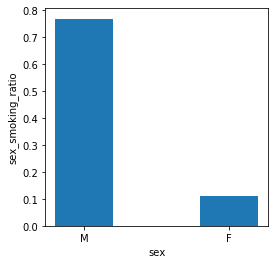

```python
sex_group = ['M','F']

plt.figure(figsize = (4, 4))
plt.bar(sex_group, sex_smoking_ratio, width = 0.4)

plt.xlabel('sex')
plt.ylabel('sex_smoking_ratio')
```

```python
[t_stat, p] = stats.ttest_ind(data[data.sex == 1.0].smoking, data[data.sex == 2.0].smoking)
[t_stat, p]
#  통계적으로 유의한 차이(p < 0.05)가 난다.
```

```
[176.54218982356767, 0.0]
```

## 흡연 여부에 따른 당뇨병의 비율

```python
dia_ratio = data.groupby('smoking')['diabetes'].mean() #흡연자(1),비흡연자(0) 각각의 당뇨병 환자의 비율
dia_ratio
```

```
smoking
0.0    0.084123
1.0    0.107126
Name: diabetes, dtype: float64
```

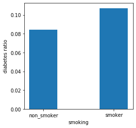

```python
smoking_group = ['non_smoker', 'smoker']

plt.figure(figsize = (4, 4))
plt.bar(smoking_group, dia_ratio, width = 0.4)

plt.xlabel('smoking')
plt.ylabel('diabetes ratio')
```

```python
[t_stat, p] = stats.ttest_ind(data[data.smoking == 0.0].diabetes, data[data.smoking == 1.0].diabetes)
[t_stat, p]
#  통계적으로 유의한 차이(p < 0.05)가 난다.
```

```
[-7.604571921894337, 2.923205147355777e-14]
```

```python
# 전체에서 당뇨의 비율
(data['diabetes']==1.0).sum()/len(data)
```

```
0.09321550741163055
```

```python
# 전체에서 당뇨가 아닌 사람의 비율
(data['diabetes']==0.0).sum()/len(data)
```

```
0.9067844925883695
```

#### >> 비율값 자체가 적은 이유는 당뇨병 환자의 데이터 자체가 매우 적기 때문이다.

## 흡연 여부에 따른 비만의 비율

```python
obs_ratio = data.groupby('smoking')['obesity'].mean() #흡연자(1),비흡연자(0) 각각의 비만의 비율
obs_ratio
```

```
smoking
0.0    0.681423
1.0    0.731463
Name: obesity, dtype: float64
```

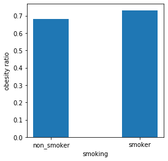

```python
plt.figure(figsize = (4, 4))
plt.bar(smoking_group, obs_ratio, width = 0.4)

plt.xlabel('smoking')
plt.ylabel('obesity ratio')
```

```python
[t_stat, p] = stats.ttest_ind(data[data.smoking == 0.0].obesity, data[data.smoking == 1.0].obesity)
[t_stat, p]
#  통계적으로 유의한 차이(p < 0.05)가 난다.
```

```
[-17.02612945502385, 9.070454805315772e-65]
```

# 흡연에 따른 3대암(위암, 간암, 폐암) 환자의 비율

## 흡연 여부에 따른 위암의 비율

```python
stomach_cancer_ratio = data.groupby('smoking')['stomach_cancer'].mean() #흡연자(1),비흡연자(0) 각각의 위암 환자의 비율
stomach_cancer_ratio
```

```
smoking
0.0    0.006514
1.0    0.012653
Name: stomach_cancer, dtype: float64
```

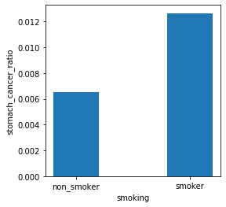

```python
plt.figure(figsize = (4, 4))
plt.bar(smoking_group, stomach_cancer_ratio, width = 0.4)

plt.xlabel('smoking')
plt.ylabel('stomach_cancer_ratio')
```

```python
[t_stat, p] = stats.ttest_ind(data[data.smoking == 0.0].stomach_cancer, data[data.smoking == 1.0].stomach_cancer)
[t_stat, p]
#  통계적으로 유의한 차이(p < 0.05)가 난다.
```

```
[-6.2670004368964, 3.719507666853017e-10]
```

```python
# 전체에서 위암의 비율
(data['stomach_cancer']==1.0).sum()/len(data)
```

```
0.008940603296361564
```

```python
# 전체에서 위암이 아닌 사람의 비율
(data['stomach_cancer']==0.0).sum()/len(data)
```

```
0.9910593967036384
```

#### >> 비율값 자체가 적은 이유는 위암 환자의 데이터 자체가 매우 적기 때문이다.

## 흡연 여부에 따른 간암의 비율

```python
liver_cancer_ratio = data.groupby('smoking')['liver_cancer'].mean()
liver_cancer_ratio
```

```
smoking
0.0    0.000686
1.0    0.002229
Name: liver_cancer, dtype: float64
```

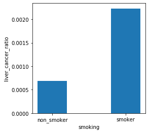

```python
plt.figure(figsize = (4, 4))
plt.bar(smoking_group, liver_cancer_ratio, width = 0.4)

plt.xlabel('smoking')
plt.ylabel('liver_cancer_ratio')
```

```python
[t_stat, p] = stats.ttest_ind(data[data.smoking == 0.0].liver_cancer, data[data.smoking == 1.0].liver_cancer)
[t_stat, p]
#  통계적으로 유의한 차이(p < 0.05)가 난다.
```

```
[-4.121374943001032, 3.774037533428494e-05]
```

```python
# 전체에서 간암의 비율
(data['liver_cancer']==1.0).sum()/len(data)
```

```
0.0012957396081683425
```

```python
# 전체에서 간암이 아닌 사람의 비율
(data['liver_cancer']==0.0).sum()/len(data)
```

```
0.9987042603918317
```

#### >> 비율값 자체가 적은 이유는 간암 환자의 데이터 자체가 매우 적기 때문이다.